# BSB632 HW1

Dilara ONAL

2024-03-18

# BSB632

## Homework I

### **Question 1**

The “Possum.csv” dataset contains various measurements of possums. Various analyzes were performed on the Possum data and the analyzes were visualized with graphs. A summary of the data set is provided below.

```
##       X                  case             site           Pop
##  Length:104         Min.   :  1.00   Min.   :1.000   Length:104
##  Class :character   1st Qu.: 26.75   1st Qu.:1.000   Class :character
##  Mode  :character   Median : 52.50   Median :3.000   Mode  :character
##                     Mean   : 52.50   Mean   :3.625
##                     3rd Qu.: 78.25   3rd Qu.:6.000
##                     Max.   :104.00   Max.   :7.000
##
##      sex                 age         head.length      skull.width
##  Length:104         Min.   :1.000   Min.   : 82.50   Min.   :50.00
##  Class :character   1st Qu.:2.250   1st Qu.: 90.67   1st Qu.:54.98
##  Mode  :character   Median :3.000   Median : 92.80   Median :56.35
##                     Mean   :3.833   Mean   : 92.60   Mean   :56.88
##                     3rd Qu.:5.000   3rd Qu.: 94.72   3rd Qu.:58.10
##                     Max.   :9.000   Max.   :103.10   Max.   :68.60
##                     NA's   :2
##   total.length    tail.length     foot.length    ear.conch.length
##  Min.   :75.00   Min.   :32.00   Min.   :60.30   Min.   :40.30
##  1st Qu.:84.00   1st Qu.:35.88   1st Qu.:64.60   1st Qu.:44.80
##  Median :88.00   Median :37.00   Median :68.00   Median :46.80
##  Mean   :87.09   Mean   :37.01   Mean   :68.46   Mean   :48.13
##  3rd Qu.:90.00   3rd Qu.:38.00   3rd Qu.:72.50   3rd Qu.:52.00
##  Max.   :96.50   Max.   :43.00   Max.   :77.90   Max.   :56.20
##                                  NA's   :1
##       eye         chest.girth    belly.girth
##  Min.   :12.80   Min.   :22.0   Min.   :25.00
##  1st Qu.:14.40   1st Qu.:25.5   1st Qu.:31.00
##  Median :14.90   Median :27.0   Median :32.50
##  Mean   :15.05   Mean   :27.0   Mean   :32.59
##  3rd Qu.:15.72   3rd Qu.:28.0   3rd Qu.:34.12
##  Max.   :17.80   Max.   :32.0   Max.   :40.00
##
```

**a )** The data set was read as a data frame, then the possum with the highest total length and the gender of this possum were found.

Information about the possum with the highest total length:

```
##      X case site Pop sex age head.length skull.width total.length tail.length
## 21 C54   21    1 Vic   f   3        95.9        58.1         96.5        39.5
##    foot.length ear.conch.length  eye chest.girth belly.girth
## 21        77.9             52.9 14.2          30          40
```

The output was analyzed and it was observed that the gender of the possum with the highest total length was **female**.

**b )** A graph was created to show the relationship between tail and head length in the Possum dataset. Possums from Victoria and other regions were shown separately on the chart.

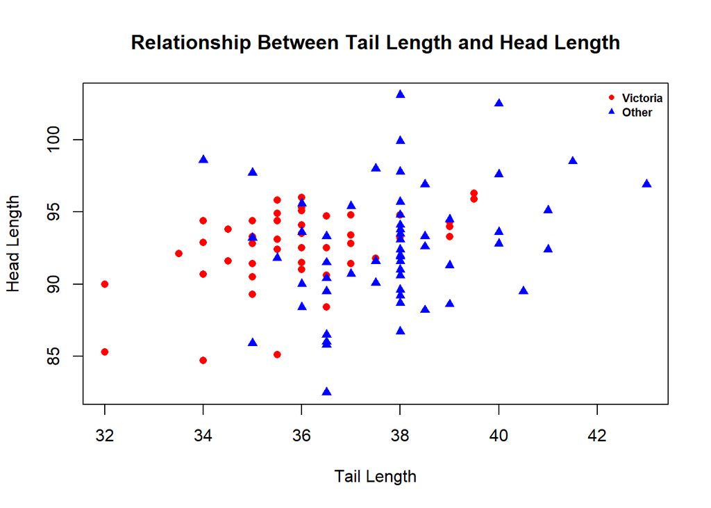

As indicated in the plot, blue triangle data points represent possums from other regions and red circle data points represent possums from Victorian regions. When the graph is analyzed, it can be said that the data obtained from the Victoria region is generally shorter in terms of tail length, but when looking at the relationship with head length, no significant difference was observed in the two groups.

```r
mean_tail_length <- tapply(possum_data$tail.length, possum_data$sex, mean)
smallest_tail_gender <- names(mean_tail_length)[which.min(mean_tail_length)]
print(mean_tail_length)
```

```
##        f        m
## 37.10465 36.94262
```

```r
mean_total_length <- tapply(possum_data$total.length, possum_data$sex, mean)
smallest_total_gender <- names(mean_total_length)[which.min(mean_total_length)]
print(mean_total_length)
```

```
##        f        m
## 87.90698 86.51148
```

The analysis using the **dplyr** library was repeated. Below are the codes written with the dplyr library.

```r
library(dplyr)
```

```r
possum_genders <- group_by(possum_data, sex)

mean_tail <- summarise(possum_genders, mean(tail.length))
smallest_tail <- mean_tail$sex[which.min(mean_tail$`mean(tail.length)`)]
print(mean_tail)
```

```
## # A tibble: 2 × 2
##   sex   `mean(tail.length)`
##   <chr>               <dbl>
## 1 f                    37.1
## 2 m                    36.9
```

```r
mean_total <- summarise(possum_genders, mean(total.length))
smallest_total <- mean_total$sex[which.min(mean_total$`mean(total.length)`)]
print(mean_total)
```

```
## # A tibble: 2 × 2
##   sex   `mean(total.length)`
##   <chr>                <dbl>
## 1 f                     87.9
## 2 m                     86.5
```

As a result of the analysis made using the Dplyr library, it was observed that the data obtained were the same. It was observed that the output of this code was printed more regularly.

**d )** The average tail lengths of male and female possums and those of possums in Victoria and other regions were calculated.

Results of mean of tail lengths male and female that from Victoria ans from other regions:

```
##      other      Vic
## f 38.07895 36.33333
## m 37.75641 35.50000
```

Results of mean of tail lengths male and female that from Victoria ans from other regions with use dplyr:

```
## # A tibble: 4 × 3
##   sex   Pop   `mean(tail.length)`
##   <chr> <chr>               <dbl>
## 1 f     Vic                  36.3
## 2 f     other                38.1
## 3 m     Vic                  35.5
## 4 m     other                37.8
```

**e )** The mean of each numerical column was calculated for seven different site where possums were captured. There are missing data in some columns. To ignore this data, rm.na was used for the relevant input parameter. Location information with the shortest and tallest possums on average was obtained.

```
##   site  X case site Pop sex      age head.length skull.width total.length
## 1    1 NA 17.0    1  NA  NA 4.181818    93.72424    57.19697     89.71212
## 2    2 NA 40.0    2  NA  NA 3.545455    89.73846    55.27692     81.76923
## 3    3 NA 50.0    3  NA  NA 4.285714    94.57143    58.90000     88.07143
## 4    4 NA 57.0    4  NA  NA 3.285714    97.61429    61.68571     92.24286
## 5    5 NA 67.0    5  NA  NA 4.307692    92.17692    56.23077     86.92308
## 6    6 NA 80.0    6  NA  NA 3.307692    89.24615    54.19231     84.53846
## 7    7 NA 95.5    7  NA  NA 3.444444    92.63333    57.23333     85.69444
##   tail.length foot.length ear.conch.length      eye chest.girth belly.girth
## 1    36.37879    72.99697         52.57576 15.02424    27.87879    33.27273
## 2    34.80769    70.75000         51.20000 14.48462    26.34615    31.11538
## 3    37.21429    66.60000         45.25714 16.07143    27.57143    34.85714
## 4    39.71429    68.92857         45.84286 15.47143    29.64286    34.57143
## 5    37.65385    64.73077         43.86923 15.38462    26.65385    32.03846
## 6    37.65385    63.06923         43.96923 15.33846    25.23077    31.50000
## 7    37.69444    65.73889         45.85556 14.47222    26.13889    31.91667
```

```
## [1] "Longest possums on average according to site: 4"
```

```
## [1] "Smallest possums on average according to site: 2"
```

The analysis was repeated using the dplyr package. Added an additional column in the output data frame in the dplyr analysis that will report the number of data points for each site. Below is the output of the code written using the dplyr package.

```
## # A tibble: 7 × 13
##    site  case   age head.length skull.width total.length tail.length foot.length
##   <int> <dbl> <dbl>       <dbl>       <dbl>        <dbl>       <dbl>       <dbl>
## 1     1  17    4.18        93.7        57.2         89.7        36.4        73.0
## 2     2  40    3.55        89.7        55.3         81.8        34.8        70.8
## 3     3  50    4.29        94.6        58.9         88.1        37.2        66.6
## 4     4  57    3.29        97.6        61.7         92.2        39.7        68.9
## 5     5  67    4.31        92.2        56.2         86.9        37.7        64.7
## 6     6  80    3.31        89.2        54.2         84.5        37.7        63.1
## 7     7  95.5  3.44        92.6        57.2         85.7        37.7        65.7
## # ℹ 5 more variables: ear.conch.length <dbl>, eye <dbl>, chest.girth <dbl>,
## #   belly.girth <dbl>, data_points <int>
```

```
## [1] "Longest possums on average according to site with dplyr: 4"
```

```
## [1] "Smallest possums on average according to site with dplyr: 2"
```

Plots were drawn to observe the relationship between tail and head length in seven different site and their relationships were checked.

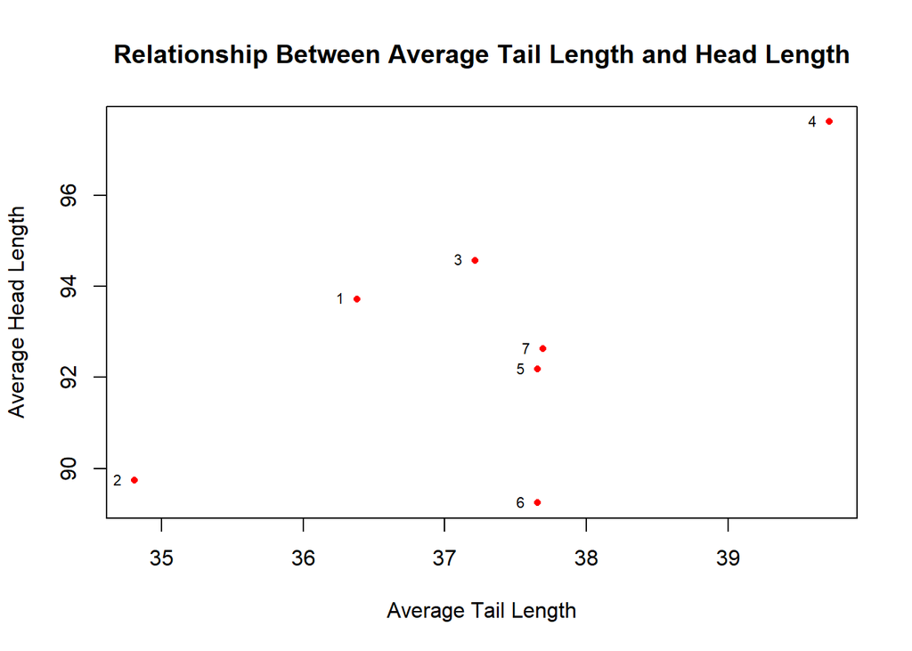

When looking at the graph of average head and tail lengths, it can be said that the longest and shortest lengths before are in the expected position on the graph. When looking at the average head length, the general distribution is observed to be in the range of 92-95, and when looking at the tail length, it is observed to be in the range of 35-38. The graph also confirmed that site 2 has the shortest possums and site 4 has the longest average possums.

**f )** The average ages of possums in the Possum dataset were calculated. Then, using the dplyr package, a new column was made using the labels “young” for possums with below average age and “old” for possums with above average age. This column was added to the dataset and a few rows from the new dataset were output as a summary.

```
## [1] 3.833333
```

```
##     X case site Pop sex age head.length skull.width total.length tail.length
## 1  C3    1    1 Vic   m   8        94.1        60.4         89.0        36.0
## 2  C5    2    1 Vic   f   6        92.5        57.6         91.5        36.5
## 3 C10    3    1 Vic   f   6        94.0        60.0         95.5        39.0
## 4 C15    4    1 Vic   f   6        93.2        57.1         92.0        38.0
## 5 C23    5    1 Vic   f   2        91.5        56.3         85.5        36.0
## 6 C24    6    1 Vic   f   1        93.1        54.8         90.5        35.5
##   foot.length ear.conch.length  eye chest.girth belly.girth age.groups
## 1        74.5             54.5 15.2        28.0          36        old
## 2        72.5             51.2 16.0        28.5          33        old
## 3        75.4             51.9 15.5        30.0          34        old
## 4        76.1             52.2 15.2        28.0          34        old
## 5        71.0             53.2 15.1        28.5          33      young
## 6        73.2             53.6 14.2        30.0          32      young
```

```
## # A tibble: 2 × 2
##   age.groups max_skull_width
##   <chr>                <dbl>
## 1 old                   68.6
## 2 young                 67.7
```

The maximum skull width of young and old possums was checked. As a result of the analysis, the maximum skull width of old and young possums was observed to be very close to each other.

```
## # A tibble: 4 × 3
##   age.groups sex   max_skull_width
##   <chr>      <chr>           <dbl>
## 1 old        f                60
## 2 old        m                68.6
## 3 young      f                67.7
## 4 young      m                64.2
```

### **Question 2**

Matrix A was created and necessary changes were made on this matrix. The changes were performed both with and without vectorization. Codes written to show the difference between vectorized and non-vectorized codes are included.

```
##       [,1] [,2]  [,3]  [,4] [,5]
## [1,] -3.20  0.0  0.10  2.40  7.5
## [2,]  0.27 -4.3 -0.03 -0.07  0.0
## [3,] -9.00  0.0  6.20 -1.00 -1.2
```

**a )** The number of positive elements in matrix A was counted.

**With vectorization**

```r
num_positive <- sum(A > 0)
print(num_positive)
```

```
## [1] 5
```

**Without vectorization**

```r
num_pos <- 0
for (i in 1:nrow(A)) {
  for (j in 1:ncol(A)) {
    if (A[i, j] > 0) {
      num_pos<- num_pos + 1
    }
  }
}
print(num_pos)
```

```
## [1] 5
```

**b )** The absolute value of each element in the matrix less than -0.5 was taken and a new matrix was created.

**With vectorization**

```r
abs_value <- ifelse(A < -0.5, abs(A), A)
print(abs_value)
```

```
##      [,1] [,2]  [,3]  [,4] [,5]
## [1,] 3.20  0.0  0.10  2.40  7.5
## [2,] 0.27  4.3 -0.03 -0.07  0.0
## [3,] 9.00  0.0  6.20  1.00  1.2
```

**Without vectorization**

```r
abs_A <- matrix(0, nrow = nrow(A), ncol = ncol(A))
for (i in 1:nrow(A)) {
  for (j in 1:ncol(A)) {
    if (A[i, j] < -0.5) {
      abs_A[i, j] <- abs(A[i, j])
    } else {
      abs_A[i, j] <- A[i, j]
    }
  }
}
print(abs_A)
```

```
##      [,1] [,2]  [,3]  [,4] [,5]
## [1,] 3.20  0.0  0.10  2.40  7.5
## [2,] 0.27  4.3 -0.03 -0.07  0.0
## [3,] 9.00  0.0  6.20  1.00  1.2
```

**c )** All zeros in the created matrix were replaced with -10. In this way, the desired changes were made on the matrix.

**With vectorization**

```r
result_A <- replace(abs_value,  abs_value == 0, -10)
print(result_A)
```

```
##      [,1]  [,2]  [,3]  [,4]  [,5]
## [1,] 3.20 -10.0  0.10  2.40   7.5
## [2,] 0.27   4.3 -0.03 -0.07 -10.0
## [3,] 9.00 -10.0  6.20  1.00   1.2
```

**Without vectorization**

```r
result_A_mat <- matrix(0, nrow = nrow(abs_A), ncol = ncol(abs_A))
for (i in 1:nrow(abs_A)) {
  for (j in 1:ncol(abs_A)) {
    if (abs_A[i, j] == 0) {
      result_A_mat[i, j] <- -10
    } else {
      result_A_mat[i, j] <- abs_A[i, j]
    }
  }
}
print(result_A_mat)
```

```
##      [,1]  [,2]  [,3]  [,4]  [,5]
## [1,] 3.20 -10.0  0.10  2.40   7.5
## [2,] 0.27   4.3 -0.03 -0.07 -10.0
## [3,] 9.00 -10.0  6.20  1.00   1.2
```